# Trabajo Estadística 2

`Gonzalo Uriel Quintanilla Villanueva``

`22/10/2021`

```r
library(rmdformats)
library(rio)
data1<- import("C:/Users/GONZALO/Desktop/CAPITULO_300_persona.sav")
```

##LIMPIEZA DE LA BASE DE DATOS

```r
str(data1$C200_P7)
```

```
##  num [1:38204] 2 1 1 1 2 1 1 2 1 2 ...
##  - attr(*, "label")= chr "7. SEXO"
##  - attr(*, "format.spss")= chr "F11.0"
##  - attr(*, "display_width")= int 7
##  - attr(*, "labels")= Named num [1:2] 1 2
##   ..- attr(*, "names")= chr [1:2] "Hombre" "Mujer"
```

```r
str(data1$C200_P8_A)
```

```
##  num [1:38204] 48 47 59 62 60 27 84 65 33 23 ...
##  - attr(*, "label")= chr "8. ¿QUÉ EDAD TIENE EN AÑOS CUMPLIDOS? - AÑOS"
##  - attr(*, "format.spss")= chr "F11.0"
##  - attr(*, "display_width")= int 7
```

```r
str(data1$C300_P11A_1)
```

```
##  num [1:38204] 2 2 3 3 2 4 2 1 NA NA ...
##  - attr(*, "label")= chr "11A. ¿QUÉ TANTA CONFIANZA LE INSPIRA 1. La Policía Nacional del Perú?"
##  - attr(*, "format.spss")= chr "F11.0"
##  - attr(*, "display_width")= int 7
##  - attr(*, "labels")= Named num [1:4] 1 2 3 4
##   ..- attr(*, "names")= chr [1:4] "Nada confiable?" "Poco confiable?" "Algo confiable?" "Muy confiable?"
```

```r
str(data1$C300_P11A_2)
```

```
##  num [1:38204] NA 2 3 4 4 4 NA NA NA NA ...
##  - attr(*, "label")= chr "11A. ¿QUÉ TANTA CONFIANZA LE INSPIRA 2.El Serenazgo?"
##  - attr(*, "format.spss")= chr "F11.0"
##  - attr(*, "display_width")= int 7
##  - attr(*, "labels")= Named num [1:4] 1 2 3 4
##   ..- attr(*, "names")= chr [1:4] "Nada confiable?" "Poco confiable?" "Algo confiable?" "Muy confiable?"
```

```r
str(data1$C300_P11A_3)
```

```
##  num [1:38204] NA NA 1 NA NA NA NA NA NA NA ...
##  - attr(*, "label")= chr "11A. ¿QUÉ TANTA CONFIANZA LE INSPIRA 3.El Ministerio Público/ Fiscalía?"
##  - attr(*, "format.spss")= chr "F11.0"
##  - attr(*, "display_width")= int 7
##  - attr(*, "labels")= Named num [1:4] 1 2 3 4
##   ..- attr(*, "names")= chr [1:4] "Nada confiable?" "Poco confiable?" "Algo confiable?" "Muy confiable?"
```

```r
str(data1$C300_P11A_4)
```

```
##  num [1:38204] NA NA 1 NA NA NA NA NA NA NA ...
##  - attr(*, "label")= chr "11A. ¿QUÉ TANTA CONFIANZA LE INSPIRA 4. El Poder Judicial?"
##  - attr(*, "format.spss")= chr "F11.0"
##  - attr(*, "display_width")= int 7
##  - attr(*, "labels")= Named num [1:4] 1 2 3 4
##   ..- attr(*, "names")= chr [1:4] "Nada confiable?" "Poco confiable?" "Algo confiable?" "Muy confiable?"
```

```r
str(data1$C300_P11A_5)
```

```
##  num [1:38204] NA NA NA NA NA NA NA NA NA NA ...
##  - attr(*, "label")= chr "11A. ¿QUÉ TANTA CONFIANZA LE INSPIRA 5. El Instituto Nacional Penitenciario/ INPE?"
##  - attr(*, "format.spss")= chr "F11.0"
##  - attr(*, "display_width")= int 7
##  - attr(*, "labels")= Named num [1:4] 1 2 3 4
##   ..- attr(*, "names")= chr [1:4] "Nada confiable?" "Poco confiable?" "Algo confiable?" "Muy confiable?"
```

```r
str(data1$ESTRATO_SOCIOE)
```

```
##  chr [1:38204] "5" "5" "5" "5" "5" "5" "5" "5" "5" "5" "5" "5" "5" "5" "5" ...
##  - attr(*, "label")= chr "Estrato Sociodemográfico"
##  - attr(*, "format.spss")= chr "A1"
##  - attr(*, "display_width")= int 7
##  - attr(*, "labels")= Named chr [1:5] "1" "2" "3" "4" ...
##   ..- attr(*, "names")= chr [1:5] "Alto" "Medio Alto" "Medio" "Medio Bajo" ...
```

```r
str(data1$REGIÓN)
```

```
##  num [1:38204] 3 3 3 3 3 3 3 3 2 2 ...
##  - attr(*, "label")= chr "Región Natural"
##  - attr(*, "format.spss")= chr "F12.0"
##  - attr(*, "display_width")= int 7
##  - attr(*, "labels")= Named num [1:3] 1 2 3
##   ..- attr(*, "names")= chr [1:3] "Costa" "Sierra" "Selva"
```

```r
data1$C200_P7 <- as.factor(data1$C200_P7)
```

```r
library(car)
data1$ESTRATO_SOCIOE = recode(data1$ESTRATO_SOCIOE, "1= 1 ; 2= 1 ; 3= 2; 4=3; 5=3")
data1$ESTRATO_SOCIOE = as.ordered(data1$ESTRATO_SOCIOE)
levels(data1$ESTRATO_SOCIOE) <- c("Alto", "Medio", "Bajo")
table(data1$ESTRATO_SOCIOE)
```

```
##
##  Alto Medio  Bajo
## 12651  9377 16176
```

```r
levels(data1$C200_P7) <- c("Hombre", "Mujer")
table(data1$C200_P7)
```

```
##
## Hombre  Mujer
##  18095  20109
```

```r
#Confianza Institucional
data1$Confianza <- c(data1$C300_P11A_1 + data1$C300_P11A_2 + data1$C300_P11A_3 + data1$C300_P11A_4
                     + data1$C300_P11A_5)
summary(data1$Confianza)
```

```
##    Min. 1st Qu.  Median    Mean 3rd Qu.    Max.    NA's
##    5.00    8.00   10.00    9.79   12.00   20.00   25634
```

```r
data1$Confianza = as.numeric(data1$Confianza)
data1$Confianza = ((data1$Confianza - 5)/15)*10
summary(data1$Confianza)
```

```
##    Min. 1st Qu.  Median    Mean 3rd Qu.    Max.    NA's
##   0.000   2.000   3.333   3.194   4.667  10.000   25634
```

```r
#Percepción de Seguridad en Lugares públicos
data1$Seguridad_LP <- c (data1$C300_P1_2 + data1$C300_P1_3 + data1$C300_P1_4 + data1$C300_P1_5
                       + data1$C300_P1_6 + data1$C300_P1_7 + data1$C300_P1_10)
summary(data1$Seguridad_LP)
```

```
##    Min. 1st Qu.  Median    Mean 3rd Qu.    Max.
##    7.00   18.00   21.00   20.95   23.00   35.00
```

```r
data1$Seguridad_LP = as.numeric(data1$Seguridad_LP)
data1$Seguridad_LP = ((data1$Seguridad_LP - 7)/28)*10
summary(data1$Seguridad_LP)
```

```
##    Min. 1st Qu.  Median    Mean 3rd Qu.    Max.
##   0.000   3.929   5.000   4.980   5.714  10.000
```

```r
#Percepción de Seguridad Lugares Privados
data1$Seguridad_LPrv <- c (data1$C300_P1_1 + data1$C300_P1_8 + data1$C300_P1_11)
summary(data1$Seguridad_LPrv)
```

```
##    Min. 1st Qu.  Median    Mean 3rd Qu.    Max.
##    3.00    9.00   10.00   10.05   12.00   15.00
```

```r
data1$Seguridad_LPrv = as.numeric(data1$Seguridad_LPrv)
data1$Seguridad_LPrv = ((data1$Seguridad_LPrv - 3)/12)*10
summary(data1$Seguridad_LPrv)
```

```
##    Min. 1st Qu.  Median    Mean 3rd Qu.    Max.
##   0.000   5.000   5.833   5.878   7.500  10.000
```

```r
#Delincuencia
data1$C300_P6_4 = as.factor(data1$C300_P6_4)
levels(data1$C300_P6_4) <- c("Disminuyó", "Se Mantuvo", "Aumentó")
table(data1$C300_P6_4)
```

```
##
##  Disminuyó Se Mantuvo    Aumentó
##       2381      11197      24626
```

```r
#Vigilancia
str(data1$C300_P13_1)
```

```
##  num [1:38204] 3 3 NA 3 NA NA NA NA NA 3 ...
##  - attr(*, "label")= chr "13. ¿CÓMO CALIFICA USTED LA VIGILANCIA DE: 1. ¿La Policía Nacional del Perú?"
##  - attr(*, "format.spss")= chr "F11.0"
##  - attr(*, "display_width")= int 7
##  - attr(*, "labels")= Named num [1:5] 1 2 3 4 5
##   ..- attr(*, "names")= chr [1:5] "Muy mala?" "Mala?" "Buena?" "Muy buena?" ...
```

```r
str(data1$C300_P13_2)
```

```
##  num [1:38204] NA NA NA NA 3 NA NA NA NA NA ...
##  - attr(*, "label")= chr "13. ¿CÓMO CALIFICA USTED LA VIGILANCIA DE: 2. ¿El Serenazgo?"
##  - attr(*, "format.spss")= chr "F11.0"
##  - attr(*, "display_width")= int 7
##  - attr(*, "labels")= Named num [1:5] 1 2 3 4 5
##   ..- attr(*, "names")= chr [1:5] "Muy mala?" "Mala?" "Buena?" "Muy buena?" ...
```

```r
data1$Vigilancia = c(data1$C300_P13_1 + data1$C300_P13_2)
summary(data1$Vigilancia)
```

```
##    Min. 1st Qu.  Median    Mean 3rd Qu.    Max.    NA's
##   2.000   4.000   6.000   5.389   6.000  10.000   25249
```

```r
data1$Vigilancia = as.numeric(data1$Vigilancia)
data1$Vigilancia = ((data1$Vigilancia - 2)/8)*10
summary(data1$Vigilancia)
```

```
##    Min. 1st Qu.  Median    Mean 3rd Qu.    Max.    NA's
##   0.000   2.500   5.000   4.237   5.000  10.000   25249
```

#Elegir solo los datos obtenidos en Lima metropolitana

```r
data1$NOMBREDD = as.factor(data1$NOMBREDD)
s0 = subset(data1, NOMBREPV =="LIMA")
```

#Elegir solo las variables que son idóneas para el caso y creamos una Nueva Base de Datos, pero solo de Lima metropolitana

```r
data= subset(s0, select = c(NOMBREPV, NOMBREDI, C200_P7, C200_P8_A, C300_P6_4, Confianza ,Seguridad_LP,
                            Seguridad_LPrv, Vigilancia, ESTRATO_SOCIOE))
data = na.omit(data)
```

```r
names(data)
```

```
##  [1] "NOMBREPV"       "NOMBREDI"       "C200_P7"        "C200_P8_A"
##  [5] "C300_P6_4"      "Confianza"      "Seguridad_LP"   "Seguridad_LPrv"
##  [9] "Vigilancia"     "ESTRATO_SOCIOE"
```

```r
names(data) <- c("Ciudad", "Distrito", "Sexo", "Edad", "Delincuencia", "Confianza","Seguridad_LP",
                 "Seguridad_LPrv", "Vigilancia", "Estrato_Sociodemográfico")
names(data)
```

```
##  [1] "Ciudad"                   "Distrito"
##  [3] "Sexo"                     "Edad"
##  [5] "Delincuencia"             "Confianza"
##  [7] "Seguridad_LP"             "Seguridad_LPrv"
##  [9] "Vigilancia"               "Estrato_Sociodemográfico"
```

**Variables:** Delincuencia -> Percepción ciudadana respecto a la delincuencia Confianza -> Confianza en las instituciones como la PNP, Serenzargo, Poder Judicial, etc. Seguridad_LP -> Percepción sobre la seguridad en lugares públicos Seguridad_LPrv -> Percepción sobre la seugridad en lugares privados Vigilancia -> Percepción sobre qué tanto hay vigilancia policial y de serenazgo en cada zona

```r
library(fastDummies)
data=dummy_cols(data, select_columns = c("Estrato_Sociodemográfico"))
```

```r
data$Estrato_Sociodemográfico_Alto <- as.factor(data$Estrato_Sociodemográfico_Alto)
data$Estrato_Sociodemográfico_Medio <- as.factor(data$Estrato_Sociodemográfico_Medio)
data$Estrato_Sociodemográfico_Bajo <- as.factor(data$Estrato_Sociodemográfico_Bajo)
```

```r
#Se remueve las bases que no son de utilidad
rm(list = c("data1", "s0"))
```

Todo lo anterior se hizo para limpiar la data y escoger ciertas variables que serán de utilidad para el estudio del caso. La nueva base de datos se llama “data”

#Media de Tendencia central de la variables:

*Seguridad en Lugares Públicos*

```r
summary(data$Seguridad_LP)
```

```
##    Min. 1st Qu.  Median    Mean 3rd Qu.    Max.
##   0.000   3.929   4.643   4.881   5.714  10.000
```

*Sexo*

```r
summary(data$Sexo)
```

```
## Hombre  Mujer
##   1585   1508
```

*Edad*

```r
summary(data$Edad)
```

```
##    Min. 1st Qu.  Median    Mean 3rd Qu.    Max.
##   15.00   35.00   47.00   47.97   61.00   97.00
```

*Confianza*

```r
summary(data$Confianza)
```

```
##    Min. 1st Qu.  Median    Mean 3rd Qu.    Max.
##   0.000   2.000   3.333   3.378   4.667  10.000
```

```r
summary(data$Estrato_Sociodemográfico)
```

```
##  Alto Medio  Bajo
##  1812   697   584
```

#Medidas de dispersión de las variable:

*Edad* -> Solo hay medidas de dispersión de esta variable al ser una variable numérica

```r
#Rango Intercuartílico
quantile(data$Edad,0.75)-quantile(data$Edad,0.25)
```

```
## 75%
##  26
```

```r
#Varianza
var(data$Edad)
```

```
## [1] 302.6096
```

```r
#Desv. Estándar
sd(data$Edad)
```

```
## [1] 17.39568
```

```r
#Coef. Variación
sd(data$Edad)/mean(data$Edad)
```

```
## [1] 0.3626493
```

Una posible prueba estadística a utilizar es la *Regresión Logística Ordinal*, pues la variable dependiente de Delincuencia se categoriza como ordinal.

```r
library(MASS)
modelo <- polr(Delincuencia ~ Sexo + Edad + Confianza + Seguridad_LP + Seguridad_LPrv +
                 Estrato_Sociodemográfico_Alto + Estrato_Sociodemográfico_Medio, data = data, Hess=T)
summary(modelo)
```

```
## Call:
## polr(formula = Delincuencia ~ Sexo + Edad + Confianza + Seguridad_LP +
##     Seguridad_LPrv + Estrato_Sociodemográfico_Alto + Estrato_Sociodemográfico_Medio,
##     data = data, Hess = T)
##
## Coefficients:
##                                    Value Std. Error t value
## SexoMujer                        0.12844   0.072434  1.7732
## Edad                             0.00355   0.002169  1.6368
## Confianza                       -0.20154   0.020751 -9.7122
## Seguridad_LP                    -0.29043   0.035790 -8.1150
## Seguridad_LPrv                  -0.05676   0.026603 -2.1336
## Estrato_Sociodemográfico_Alto1  -0.79505   0.105577 -7.5306
## Estrato_Sociodemográfico_Medio1  0.09524   0.122073  0.7802
##
## Intercepts:
##                      Value    Std. Error t value
## Disminuyó|Se Mantuvo  -4.9687   0.2375   -20.9179
## Se Mantuvo|Aumentó    -2.7414   0.2237   -12.2536
##
## Residual Deviance: 5430.503
## AIC: 5448.503
```

```r
summary_table <- coef(summary(modelo))
summary_table
```

```
##                                        Value  Std. Error     t value
## SexoMujer                        0.128440804 0.072434219   1.7732062
## Edad                             0.003550357 0.002169043   1.6368310
## Confianza                       -0.201537789 0.020750901  -9.7122428
## Seguridad_LP                    -0.290433636 0.035789760  -8.1149926
## Seguridad_LPrv                  -0.056762095 0.026603310  -2.1336478
## Estrato_Sociodemográfico_Alto1  -0.795052472 0.105576829  -7.5305583
## Estrato_Sociodemográfico_Medio1  0.095239734 0.122073380   0.7801843
## Disminuyó|Se Mantuvo            -4.968680512 0.237532811 -20.9178702
## Se Mantuvo|Aumentó              -2.741400077 0.223722477 -12.2535747
```

```r
pval <- pnorm(abs(summary_table[, "t value"]),lower.tail = FALSE)* 2
pval
```

```
##                       SexoMujer                            Edad
##                    7.619455e-02                    1.016658e-01
##                       Confianza                    Seguridad_LP
##                    2.673876e-22                    4.858145e-16
##                  Seguridad_LPrv  Estrato_Sociodemográfico_Alto1
##                    3.287162e-02                    5.052382e-14
## Estrato_Sociodemográfico_Medio1            Disminuyó|Se Mantuvo
##                    4.352824e-01                    3.681937e-97
##              Se Mantuvo|Aumentó
##                    1.607509e-34
```

```r
summary_table <- cbind(summary_table, "p value" = pval)
summary_table
```

```
##                                        Value  Std. Error     t value
## SexoMujer                        0.128440804 0.072434219   1.7732062
## Edad                             0.003550357 0.002169043   1.6368310
## Confianza                       -0.201537789 0.020750901  -9.7122428
## Seguridad_LP                    -0.290433636 0.035789760  -8.1149926
## Seguridad_LPrv                  -0.056762095 0.026603310  -2.1336478
## Estrato_Sociodemográfico_Alto1  -0.795052472 0.105576829  -7.5305583
## Estrato_Sociodemográfico_Medio1  0.095239734 0.122073380   0.7801843
## Disminuyó|Se Mantuvo            -4.968680512 0.237532811 -20.9178702
## Se Mantuvo|Aumentó              -2.741400077 0.223722477 -12.2535747
##                                      p value
## SexoMujer                       7.619455e-02
## Edad                            1.016658e-01
## Confianza                       2.673876e-22
## Seguridad_LP                    4.858145e-16
## Seguridad_LPrv                  3.287162e-02
## Estrato_Sociodemográfico_Alto1  5.052382e-14
## Estrato_Sociodemográfico_Medio1 4.352824e-01
## Disminuyó|Se Mantuvo            3.681937e-97
## Se Mantuvo|Aumentó              1.607509e-34
```

Se visualiza que todas las variables independientes son menores a 0.05; a excepción de las variables Sexo, Edad y Estrato Sociodemográfico Medio

```r
exp(coef(modelo))
```

```
##                       SexoMujer                            Edad
##                       1.1370541                       1.0035567
##                       Confianza                    Seguridad_LP
##                       0.8174727                       0.7479392
##                  Seguridad_LPrv  Estrato_Sociodemográfico_Alto1
##                       0.9448188                       0.4515575
## Estrato_Sociodemográfico_Medio1
##                       1.0999225
```

```r
coef(summary(modelo))
```

```
##                                        Value  Std. Error     t value
## SexoMujer                        0.128440804 0.072434219   1.7732062
## Edad                             0.003550357 0.002169043   1.6368310
## Confianza                       -0.201537789 0.020750901  -9.7122428
## Seguridad_LP                    -0.290433636 0.035789760  -8.1149926
## Seguridad_LPrv                  -0.056762095 0.026603310  -2.1336478
## Estrato_Sociodemográfico_Alto1  -0.795052472 0.105576829  -7.5305583
## Estrato_Sociodemográfico_Medio1  0.095239734 0.122073380   0.7801843
## Disminuyó|Se Mantuvo            -4.968680512 0.237532811 -20.9178702
## Se Mantuvo|Aumentó              -2.741400077 0.223722477 -12.2535747
```

Probabilidad del evento: exponencial del B0

#Ecuación del modelo Exp(Value - ((Value.x) + (Value.Y))) *Prob. del primer corte ( >= Se Mantuvo)*

```r
num = exp(-2.741400077 - ((0.128440804*1) + (0.003550357*40) + (-0.201537789*5) + (-0.290433636*3) +
                            (-0.056762095*2) + (-0.795052472*1)))
denom = 1 + num
Aumentó_SeMantuvo1= num/denom
Aumentó_SeMantuvo1
```

```
## [1] 0.4441617
```

```r
library(DescTools)
PseudoR2(modelo, which = c("Nagelkerke"))
```

```
## Nagelkerke
##  0.1440976
```

El modelo predice un 14.40% de variabilidad de la variable dependiente

##ANÁLISIS FACTORIAL EXPLOTATORIO POR COMPONENTES PRINCIPALES

```r
library(dplyr)
data2=select(data, "Edad", "Confianza", "Seguridad_LP", "Seguridad_LPrv", "Vigilancia")
summary(data2)
```

```
##       Edad         Confianza       Seguridad_LP    Seguridad_LPrv
##  Min.   :15.00   Min.   : 0.000   Min.   : 0.000   Min.   :0.000
##  1st Qu.:35.00   1st Qu.: 2.000   1st Qu.: 3.929   1st Qu.:4.167
##  Median :47.00   Median : 3.333   Median : 4.643   Median :5.000
##  Mean   :47.97   Mean   : 3.378   Mean   : 4.881   Mean   :5.323
##  3rd Qu.:61.00   3rd Qu.: 4.667   3rd Qu.: 5.714   3rd Qu.:5.833
##  Max.   :97.00   Max.   :10.000   Max.   :10.000   Max.   :9.167
##    Vigilancia
##  Min.   : 0.000
##  1st Qu.: 3.750
##  Median : 5.000
##  Mean   : 4.347
##  3rd Qu.: 5.000
##  Max.   :10.000
```

```r
library(polycor)
corMatrix=polycor::hetcor(data2)$correlations
corMatrix
```

```
##                        Edad   Confianza Seguridad_LP Seguridad_LPrv
## Edad            1.000000000 -0.02591118    0.2491678     0.03573822
## Confianza      -0.025911175  1.00000000    0.1365705     0.03809345
## Seguridad_LP    0.249167785  0.13657049    1.0000000     0.25690751
## Seguridad_LPrv  0.035738217  0.03809345    0.2569075     1.00000000
## Vigilancia      0.006587448  0.34474970    0.1887427    -0.01366698
##                  Vigilancia
## Edad            0.006587448
## Confianza       0.344749698
## Seguridad_LP    0.188742750
## Seguridad_LPrv -0.013666984
## Vigilancia      1.000000000
```

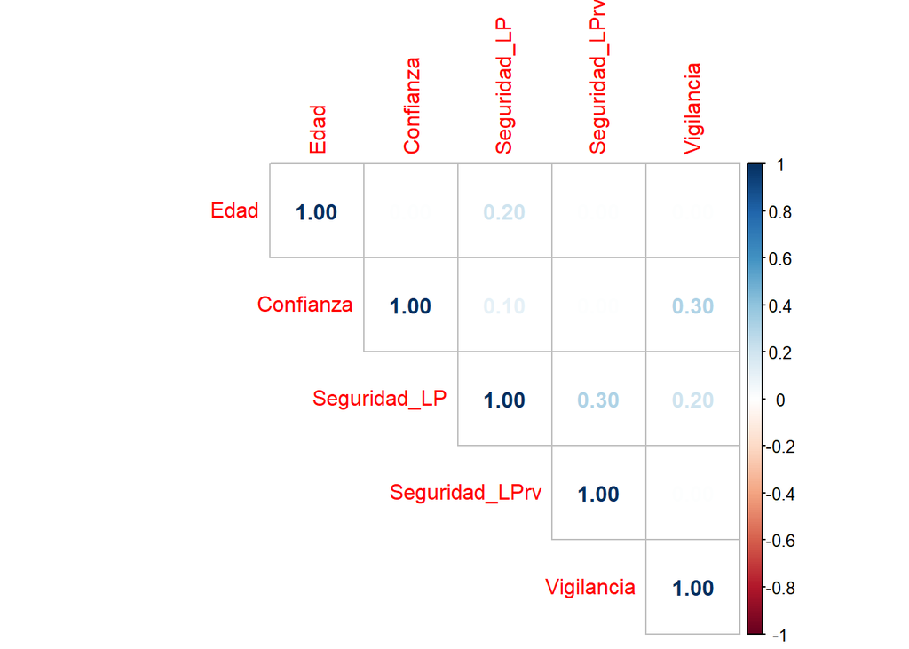

```r
library(corrplot)
correlacion<-round(cor(data2), 1)
corrplot(correlacion, method="number", type="upper")
```

```r
library(psych)
KMO(corMatrix)
```

```
## Kaiser-Meyer-Olkin factor adequacy
## Call: KMO(r = corMatrix)
## Overall MSA =  0.52
## MSA for each item =
##           Edad      Confianza   Seguridad_LP Seguridad_LPrv     Vigilancia
##           0.48           0.55           0.52           0.48           0.52
```

El Overal MSA es de 0.52. Por lo cual se puede proseguir con el estudio

```r
cortest.bartlett(corMatrix,n=nrow(data2))$p.value>0.05
```

```
## [1] FALSE
```

Se corrobora la información anterior

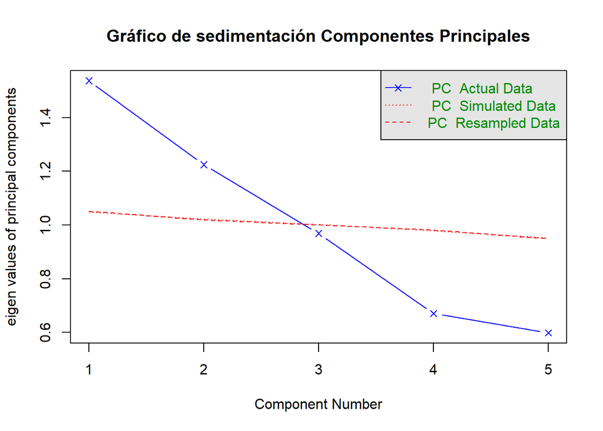

```
## Parallel analysis suggests that the number of factors =  NA  and the number of components =  2
```

```r
#Componentes Principales
fa.parallel(data2, fm="pa", fa="pc", main = "Gráfico de sedimentación Componentes Principales")
```

```r
library(factoextra)
library(FactoMineR)
```

```r
res.pca <-PCA(data2, graph = FALSE)
eig.val <-get_eig(res.pca)
eig.val
```

```
##       eigenvalue variance.percent cumulative.variance.percent
## Dim.1  1.5372496         30.74499                    30.74499
## Dim.2  1.2246995         24.49399                    55.23898
## Dim.3  0.9688105         19.37621                    74.61519
## Dim.4  0.6705549         13.41110                    88.02629
## Dim.5  0.5986855         11.97371                   100.00000
```

Haya dos eigen-values mayores a 1; por lo que R nos recomienda trabajar con 2 componentes

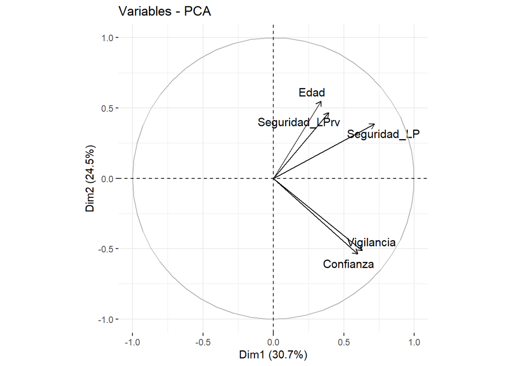

```r
fviz_pca_var(res.pca, col.var = "black",repel = TRUE)
```

```r
comp<- pca(data2,nfactors = 2,rotate = "varimax")
```

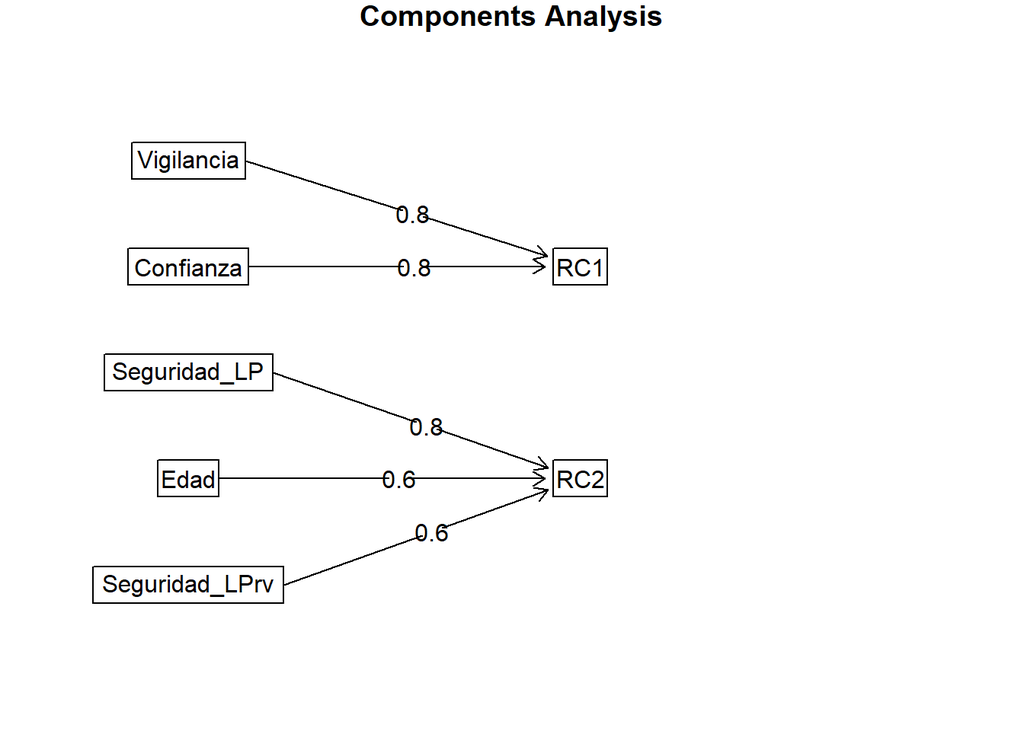

```r
fa.diagram(comp)
```

```r
#Comunalidad
sort(comp$communality)
```

```
## Seguridad_LPrv           Edad      Confianza     Vigilancia   Seguridad_LP
##      0.3732050      0.4159369      0.6476871      0.6614594      0.6636607
```

La variable Seguridad_LP (Percepción de Seguridad en Lugares Públicos) ha aportado a más componentes

```r
#Singularidad
sort(comp$uniquenesses)
```

```
##   Seguridad_LP     Vigilancia      Confianza           Edad Seguridad_LPrv
##      0.3363393      0.3385406      0.3523129      0.5840631      0.6267950
```

```r
#Complejidad
sort(comp$complexity)
```

```
##      Confianza Seguridad_LPrv     Vigilancia           Edad   Seguridad_LP
##       1.000053       1.001939       1.003727       1.063611       1.261314
```

La variable Seguridad_LP (Percepción de Seguridad en Lugares Públicos) ha aportado a más componentes

```r
comp_casos<-as.data.frame(comp$scores)#Volver score en un data frame
data$Instituciones<- comp_casos$RC1
data$Seguridad <- comp_casos$RC2
summary(data$Instituciones)
```

```
##     Min.  1st Qu.   Median     Mean  3rd Qu.     Max.
## -3.12066 -0.68839  0.04297  0.00000  0.71069  3.44476
```

```r
library(BBmisc)
data$Instituciones = normalize(data$Instituciones,
                                        method = "range",
                                        margin=2, # by column
                                        range = c(0, 100))

data$Seguridad = normalize(data$Seguridad,
                                        method = "range",
                                        margin=2, # by column
                                        range = c(0, 100))
summary(data$Seguridad)
```

```
##    Min. 1st Qu.  Median    Mean 3rd Qu.    Max.
##    0.00   35.74   43.19   44.12   51.30  100.00
```

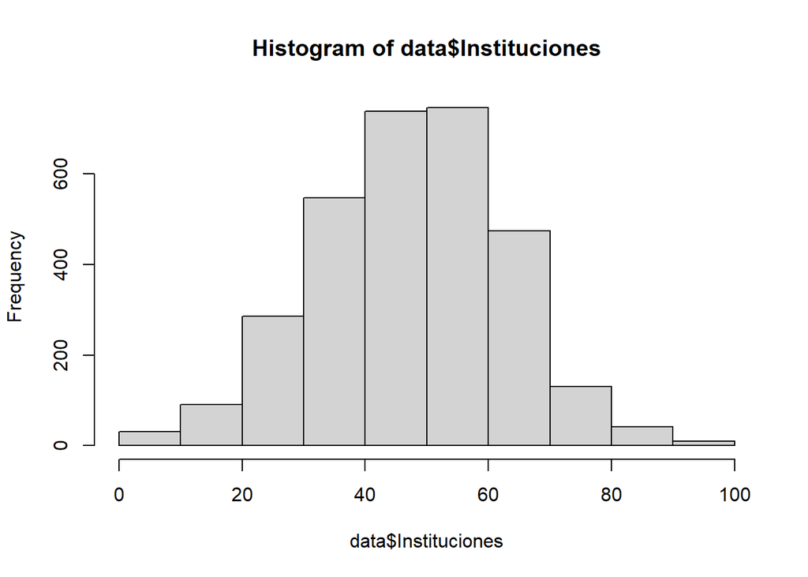

```r
hist(data$Instituciones)
```

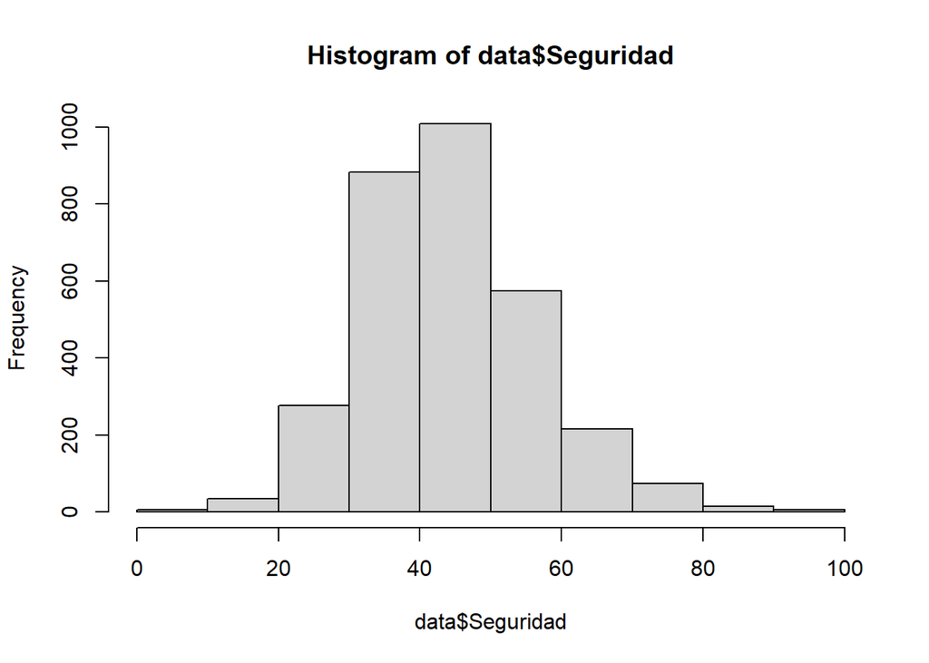

```r
hist(data$Seguridad)
```

```r
data$Delincuencia = as.ordered(data$Delincuencia)
```

```r
modelo1 <- polr(Delincuencia ~ Instituciones +Seguridad,
                data = data, Hess=T)
summary(modelo1)
```

```
## Call:
## polr(formula = Delincuencia ~ Instituciones + Seguridad, data = data,
##     Hess = T)
##
## Coefficients:
##                  Value Std. Error t value
## Instituciones -0.04315   0.002566 -16.817
## Seguridad     -0.02245   0.002981  -7.533
##
## Intercepts:
##                      Value    Std. Error t value
## Disminuyó|Se Mantuvo  -5.3691   0.2068   -25.9647
## Se Mantuvo|Aumentó    -3.1610   0.1896   -16.6689
##
## Residual Deviance: 5466.907
## AIC: 5474.907
```

```r
summary_table1 <- coef(summary(modelo1))
summary_table1
```

```
##                            Value  Std. Error    t value
## Instituciones        -0.04315045 0.002565920 -16.816753
## Seguridad            -0.02245342 0.002980665  -7.533025
## Disminuyó|Se Mantuvo -5.36905025 0.206783064 -25.964652
## Se Mantuvo|Aumentó   -3.16095651 0.189632444 -16.668859
```

```r
pval1 <- pnorm(abs(summary_table1[, "t value"]),lower.tail = FALSE)* 2
pval1
```

```
##        Instituciones            Seguridad Disminuyó|Se Mantuvo
##         1.839695e-63         4.957819e-14        1.242365e-148
##   Se Mantuvo|Aumentó
##         2.207679e-62
```

```r
summary_table1 <- cbind(summary_table1, "p value" = pval1)
summary_table1
```

```
##                            Value  Std. Error    t value       p value
## Instituciones        -0.04315045 0.002565920 -16.816753  1.839695e-63
## Seguridad            -0.02245342 0.002980665  -7.533025  4.957819e-14
## Disminuyó|Se Mantuvo -5.36905025 0.206783064 -25.964652 1.242365e-148
## Se Mantuvo|Aumentó   -3.16095651 0.189632444 -16.668859  2.207679e-62
```

Todas las variables son válidas al presentar p-values menores a 0.05

```r
exp(coef(modelo1))
```

```
## Instituciones     Seguridad
##     0.9577673     0.9777968
```

Probabilidad del evento: exponencial del B0

#Ecuación del modelo Exp(Value - ((Value.x) + (Value.Y))) *Prob. del primer corte ( >= Se Mantuvo)*

```r
num_1 = exp(-3.16095651 - ((-0.04315045*25) + (-0.02245342*50)))
denom_1 = 1 + num_1
Aumentó_SeMantuvo= num_1/denom_1
Aumentó_SeMantuvo
```

```
## [1] 0.2769735
```

```r
PseudoR2(modelo1, which = c("Nagelkerke"))
```

```
## Nagelkerke
##  0.1318478
```

El modelo predice un 13.18% de variabilidad de la variable dependiente